# **Finding The Relationship Between Emission and GDP By Countries**

##### By: Ruijie Chen

# **Introduction**

At a time when sustainable development has become a global imperative, understanding the complex interplay between economic growth and environmental impact is critical. Economic growth, often quantified as gross domestic product (GDP), drives many national policies. However, this growth is often accompanied by an increase in environmental costs, primarily in greenhouse gas emissions, which are a significant cause of global warming and climate.  
For more information about **[GDP](https://www.investopedia.com/terms/g/gdp.asp)** and **[Emission](https://energyeducation.ca/encyclopedia/Emissions)** , Click on the corresponnding links.

In this tutorial, we aim to reveal and analyze the relationship between GDP and emissions across countries using powerful data science methods. By exploring this relationship, we aim to gain insight into how economic activity is linked to environmental impacts and the extent to which rich economies contribute to greater environmental degradation or to achieving green, sustainable growth.

We will leverage a comprehensive data science pipeline, starting with the collection and management of reliable data from international databases. We will process and clean this data to ensure the accuracy of our findings. We will use statistical tools and visualization techniques to analyze the data to determine the nature of the correlation between GDP and emissions. This investigation will help us understand whether higher GDP is always associated with higher emissions, or whether countries can decouple economic growth from environmental damage.

Through research, we will find ways for different countries to strike a balance between prosperity and sustainability, and thus better understand how the world should contribute to climate change.

In this tutorial, we will use **[Python](https://www.python.org/)** some libaries that associate with it to walk through.  
We will start with importing some libraries.

```python
# imports
from bs4 import BeautifulSoup as bs
import math
import requests
import pandas as pd
import matplotlib.pyplot as plt
import numpy as np
from scipy import stats
import seaborn as sns
import statsmodels.formula.api as smf
from sklearn.linear_model import LinearRegression
from statsmodels.stats.anova import anova_lm
from sklearn.preprocessing import PolynomialFeatures
from sklearn.model_selection import train_test_split
from sklearn.metrics import mean_squared_error
```

## **Part 1: Data Collection**

##### **Getting the Data from __[Kaggle](https://www.kaggle.com/datasets?search=country)__**

To convinience, I download the needed CSV files for the tutorial. Here's the Links:  
**Emissions by Country**: https://www.kaggle.com/datasets/thedevastator/global-fossil-co2-emissions-by-country-2002-2022  
**Country, Regional and World GDP**: https://www.kaggle.com/datasets/tunguz/country-regional-and-world-gdp

First, I will load both CSV files from my local. ("Emissions by Country" and "Country, Regional and World GDP")

```python
Emission_df = pd.read_csv("Emission.csv")
GDP_df = pd.read_csv("GDP.csv")
```

```python
Emission_df.head(5)
```

|  | Country | ISO 3166-1 alpha-3 | Year | Total | Coal | Oil | Gas | Cement | Flaring | Other |
| --- | --- | --- | --- | --- | --- | --- | --- | --- | --- | --- |
| 0 | Afghanistan | AFG | 1750 | NaN | NaN | NaN | NaN | NaN | NaN | NaN |
| 1 | Afghanistan | AFG | 1751 | NaN | NaN | NaN | NaN | NaN | NaN | NaN |
| 2 | Afghanistan | AFG | 1752 | NaN | NaN | NaN | NaN | NaN | NaN | NaN |
| 3 | Afghanistan | AFG | 1753 | NaN | NaN | NaN | NaN | NaN | NaN | NaN |
| 4 | Afghanistan | AFG | 1754 | NaN | NaN | NaN | NaN | NaN | NaN | NaN |

```python
GDP_df.head(5)
```

|  | Country Name | Country Code | Year | Value |
| --- | --- | --- | --- | --- |
| 0 | Arab World | ARB | 1968 | 2.576068e+10 |
| 1 | Arab World | ARB | 1969 | 2.843420e+10 |
| 2 | Arab World | ARB | 1970 | 3.138550e+10 |
| 3 | Arab World | ARB | 1971 | 3.642691e+10 |
| 4 | Arab World | ARB | 1972 | 4.331606e+10 |

The tables above show that we have got what we need. Emissions of different materials in different countries in different years. And the GDP between different countries and years. Next, we just need to clear out the missing and unecessary data. Like the "NaN" shows above. a

## **Part 2: Data Processing**

We will mainly use **[Pandas](https://pandas.pydata.org/)** and __[Numpy](https://numpy.org/)__which are libraries of Python to achive the goal in this part.  
If you don't have it on your PC, you can use command below to install:

**pip install Pandas**  
**pip install Numpy**

First, We need to combine the two table so we can access our table easier. However, the name of the column of **GDP_df** is not quite right so we need to fix the name of the column first.

```python
GDP_df.rename(columns={'Country Name': 'Country'}, inplace=True)
GDP_df.head(5)
```

|  | Country | Country Code | Year | Value |
| --- | --- | --- | --- | --- |
| 0 | Arab World | ARB | 1968 | 2.576068e+10 |
| 1 | Arab World | ARB | 1969 | 2.843420e+10 |
| 2 | Arab World | ARB | 1970 | 3.138550e+10 |
| 3 | Arab World | ARB | 1971 | 3.642691e+10 |
| 4 | Arab World | ARB | 1972 | 4.331606e+10 |

Now, we can combine the 2 tables:

```python
combined_df = pd.merge(GDP_df, Emission_df, on=['Country', 'Year'], how='inner')
combined_df.head(5)
```

|  | Country | Country Code | Year | Value | ISO 3166-1 alpha-3 | Total | Coal | Oil | Gas | Cement | Flaring | Other |
| --- | --- | --- | --- | --- | --- | --- | --- | --- | --- | --- | --- | --- |
| 0 | Afghanistan | AFG | 1960 | 5.377778e+08 | AFG | 0.048001 | 0.014742 | 0.031169 | 0.0 | 0.002089 | 0.0 | NaN |
| 1 | Afghanistan | AFG | 1961 | 5.488889e+08 | AFG | 0.055835 | 0.020008 | 0.033346 | 0.0 | 0.002481 | 0.0 | NaN |
| 2 | Afghanistan | AFG | 1962 | 5.466667e+08 | AFG | 0.076775 | 0.033090 | 0.040443 | 0.0 | 0.003242 | 0.0 | NaN |
| 3 | Afghanistan | AFG | 1963 | 7.511112e+08 | AFG | 0.077176 | 0.028808 | 0.042812 | 0.0 | 0.005556 | 0.0 | NaN |
| 4 | Afghanistan | AFG | 1964 | 8.000000e+08 | AFG | 0.089632 | 0.032115 | 0.050913 | 0.0 | 0.006604 | 0.0 | NaN |

During the step above, we are combining the two table correspond to the column name "Country" and "Year" using mode "Inner". So the rows that do not have a data on column "Country" and "Year" will be remove automatically.|

By viewing the table above, we noticed that there are missing data in it, so we need to replace the "NaN" with 0.

```python
combined_df.fillna(0, inplace=True)
combined_df.head(5)
```

|  | Country | Country Code | Year | Value | ISO 3166-1 alpha-3 | Total | Coal | Oil | Gas | Cement | Flaring | Other |
| --- | --- | --- | --- | --- | --- | --- | --- | --- | --- | --- | --- | --- |
| 0 | Afghanistan | AFG | 1960 | 5.377778e+08 | AFG | 0.048001 | 0.014742 | 0.031169 | 0.0 | 0.002089 | 0.0 | 0.0 |
| 1 | Afghanistan | AFG | 1961 | 5.488889e+08 | AFG | 0.055835 | 0.020008 | 0.033346 | 0.0 | 0.002481 | 0.0 | 0.0 |
| 2 | Afghanistan | AFG | 1962 | 5.466667e+08 | AFG | 0.076775 | 0.033090 | 0.040443 | 0.0 | 0.003242 | 0.0 | 0.0 |
| 3 | Afghanistan | AFG | 1963 | 7.511112e+08 | AFG | 0.077176 | 0.028808 | 0.042812 | 0.0 | 0.005556 | 0.0 | 0.0 |
| 4 | Afghanistan | AFG | 1964 | 8.000000e+08 | AFG | 0.089632 | 0.032115 | 0.050913 | 0.0 | 0.006604 | 0.0 | 0.0 |

To make sure we are able to do the calculations, we need to make sure that all the numbers in the table is either float or int.

```python
combined_df.dtypes
```

```
Country                object
Country Code           object
Year                    int64
Value                 float64
ISO 3166-1 alpha-3     object
Total                 float64
Coal                  float64
Oil                   float64
Gas                   float64
Cement                float64
Flaring               float64
Other                 float64
dtype: object
```

To make sure the data is reliable and not oversize, we can filter the data with "year >=2000"

```python
combined_df = combined_df[combined_df['Year'] >= 2000]
combined_df
```

|  | Country | Country Code | Year | Value | ISO 3166-1 alpha-3 | Total | Coal | Oil | Gas | Cement | Flaring | Other |
| --- | --- | --- | --- | --- | --- | --- | --- | --- | --- | --- | --- | --- |
| 22 | Afghanistan | AFG | 2001 | 2.461666e+09 | AFG | 0.054300 | 0.003536 | 0.038708 | 0.010608 | 0.000332 | 0.001117 | 0.0 |
| 23 | Afghanistan | AFG | 2002 | 4.128821e+09 | AFG | 0.063856 | 0.002624 | 0.034639 | 0.026067 | 0.000525 | 0.000000 | 0.0 |
| 24 | Afghanistan | AFG | 2003 | 4.583644e+09 | AFG | 0.068871 | 0.004054 | 0.043788 | 0.020596 | 0.000433 | 0.000000 | 0.0 |
| 25 | Afghanistan | AFG | 2004 | 5.285466e+09 | AFG | 0.052529 | 0.003889 | 0.038579 | 0.009645 | 0.000416 | 0.000000 | 0.0 |
| 26 | Afghanistan | AFG | 2005 | 6.275074e+09 | AFG | 0.077403 | 0.004353 | 0.059288 | 0.013509 | 0.000254 | 0.000000 | 0.0 |
| ... | ... | ... | ... | ... | ... | ... | ... | ... | ... | ... | ... | ... |
| 7851 | Zimbabwe | ZWE | 2012 | 1.424249e+10 | ZWE | 0.848359 | 0.527282 | 0.278418 | 0.000000 | 0.042659 | 0.000000 | 0.0 |
| 7852 | Zimbabwe | ZWE | 2013 | 1.545177e+10 | ZWE | 0.861011 | 0.524107 | 0.302733 | 0.000000 | 0.034171 | 0.000000 | 0.0 |
| 7853 | Zimbabwe | ZWE | 2014 | 1.589105e+10 | ZWE | 0.862180 | 0.558060 | 0.268323 | 0.000000 | 0.035797 | 0.000000 | 0.0 |
| 7854 | Zimbabwe | ZWE | 2015 | 1.630467e+10 | ZWE | 0.865772 | 0.569469 | 0.254967 | 0.000000 | 0.041336 | 0.000000 | 0.0 |
| 7855 | Zimbabwe | ZWE | 2016 | 1.661996e+10 | ZWE | 0.728822 | 0.479653 | 0.217264 | 0.000000 | 0.031905 | 0.000000 | 0.0 |

2866 rows × 12 columns

Next, we need to prepare several data for our next Section:  
For instance, mean(), Standard Deviation(STD), normalize the table.  
We need to normalize the data because of the next few reasons:

- As we observed, the scale of GDP is much larger than the scale of emissions. Normalizing these values would prevent the GDP from overpowering tihe influence of emissions in machine learning models.
- Normalization allows each variable to contribute equally to the analysis, ensuring that insights derived from the data are not biased.
- Having features on a similar scale can help improve the convergence models.>

We we Normalize the data using the function below.

```python
columns_to_normalize = ['Value', 'Total', 'Coal', 'Oil', 'Gas', 'Cement', 'Flaring', 'Other']
def normalize(name,data):
    for n in name:
        current = data[n]
        current_mean = current.mean()
        current_std = current.std()
        current = (current - current_mean)/current_std
        data[n] = current
    return data
normailize_data = normalize(columns_to_normalize, combined_df)
normailize_data.head(5)
```

|  | Country | Country Code | Year | Value | ISO 3166-1 alpha-3 | Total | Coal | Oil | Gas | Cement | Flaring | Other |
| --- | --- | --- | --- | --- | --- | --- | --- | --- | --- | --- | --- | --- |
| 22 | Afghanistan | AFG | 2001 | -0.304991 | AFG | -0.722354 | -0.470732 | -0.709122 | -0.342130 | -0.701219 | -0.217461 | -0.45404 |
| 23 | Afghanistan | AFG | 2002 | -0.302797 | AFG | -0.720927 | -0.471240 | -0.710359 | -0.338393 | -0.700035 | -0.219731 | -0.45404 |
| 24 | Afghanistan | AFG | 2003 | -0.302199 | AFG | -0.720178 | -0.470443 | -0.707579 | -0.339716 | -0.700600 | -0.219731 | -0.45404 |
| 25 | Afghanistan | AFG | 2004 | -0.301275 | AFG | -0.722619 | -0.470535 | -0.709162 | -0.342363 | -0.700704 | -0.219731 | -0.45404 |
| 26 | Afghanistan | AFG | 2005 | -0.299972 | AFG | -0.718904 | -0.470277 | -0.702868 | -0.341429 | -0.701698 | -0.219731 | -0.45404 |

Now, we have our data in the same scale, which will make sure our models will work as we want.  
And we are ready for our next step.

## **Part 3: Exploratory analysis & Data viz**

In this Section, we will use **[Matplotlib](https://matplotlib.org/)** for plotting.  
First, we will have an assumption. **"The Emission should be inversely proportion to GDP"**  
We will start with using a scatter plot to check how the data is distributed.

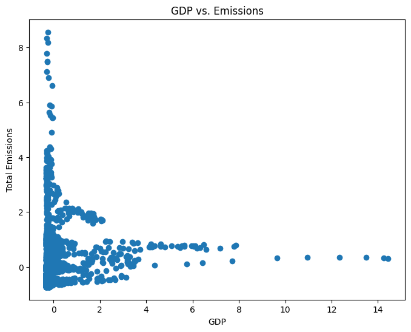

```python
plt.figure(figsize=(8, 6))
plt.scatter(normailize_data['Value'], normailize_data['Total'])
plt.title('GDP vs. Emissions')
plt.xlabel('GDP')
plt.ylabel('Total Emissions')
plt.show()
```

```python
temp_col = combined_df["Country"]
temp_col
a = []
for i in temp_col:
    if i not in a:
        a.append(i)
print(len(a))
```

```
174
```

According to the code above, we know there are 174 countries. If we directly plot the graph, there will be 174 lines which will be pretty messy. So we will use the mean to show the relationship using two graphs. **GDP vs. Time** and **Emission vs. Time**. Since we have normalize the data, it will show the relationship creectly without large gaps.

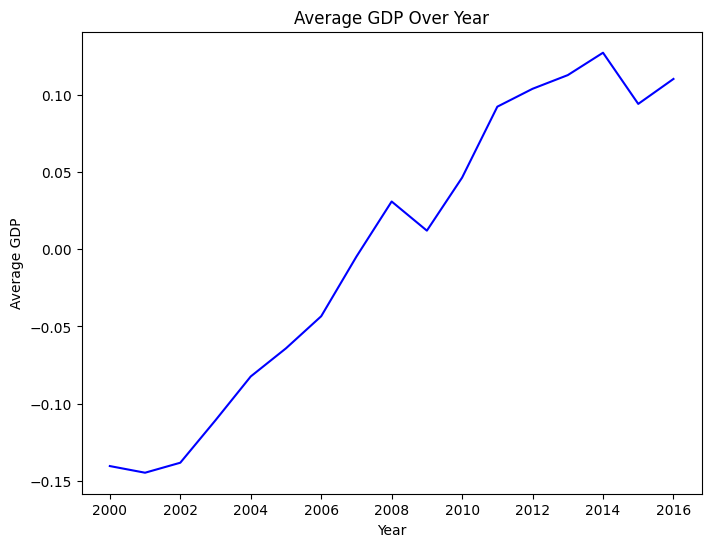

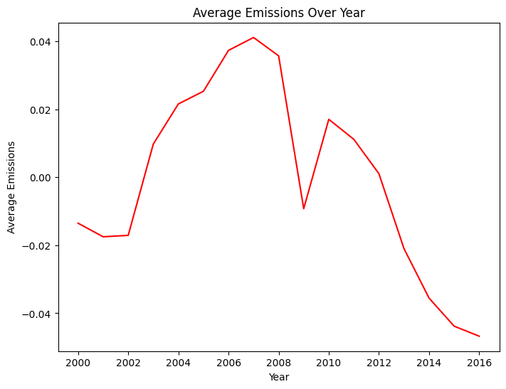

```python
aver_GDP = normailize_data.groupby('Year')['Value'].mean()
aver_Emission = normailize_data.groupby('Year')['Total'].mean()

plt.figure(figsize=(8, 6))
plt.plot(aver_GDP.index, aver_GDP.values, color='blue')
plt.title('Average GDP Over Year')
plt.xlabel('Year')
plt.ylabel('Average GDP')
plt.show()

plt.figure(figsize=(8, 6))
plt.plot(aver_Emission.index, aver_Emission.values, color='red')
plt.title('Average Emissions Over Year')
plt.xlabel('Year')
plt.ylabel('Average Emissions')
plt.show()
```

According to the line graph and scatter graph above. We can clearly know that there must be some outliers that is influencing the data. A possible reson is the difference between developed and developing countries. So next, I will try to seperate them into 2 groups by GDP using the percentage they are in.

```python
modified_1 = normailize_data.copy()
GDP_line = modified_1['Value'].quantile(0.7)

modified_1['Group'] = modified_1['Value'].apply(lambda x: 'Top 30%' if x >= GDP_line else 'Rest')

Top_30 = modified_1[modified_1['Group'] == 'Top 30%']
Rest_70 = modified_1[modified_1['Group'] == 'Rest']
Top_30.head(5)
```

|  | Country | Country Code | Year | Value | ISO 3166-1 alpha-3 | Total | Coal | Oil | Gas | Cement | Flaring | Other | Group |
| --- | --- | --- | --- | --- | --- | --- | --- | --- | --- | --- | --- | --- | --- |
| 115 | Algeria | DZA | 2004 | -0.195933 | DZA | -0.326903 | -0.439759 | -0.414098 | -0.038288 | 0.220823 | 0.218292 | -0.45404 | Top 30% |
| 116 | Algeria | DZA | 2005 | -0.172409 | DZA | -0.247999 | -0.432778 | -0.434540 | 0.104268 | 0.350672 | 0.161736 | -0.45404 | Top 30% |
| 117 | Algeria | DZA | 2006 | -0.154208 | DZA | -0.282907 | -0.427736 | -0.400637 | 0.011779 | 0.496791 | 0.170757 | -0.45404 | Top 30% |
| 118 | Algeria | DZA | 2007 | -0.130584 | DZA | -0.254104 | -0.423360 | -0.378186 | 0.018610 | 0.560584 | 0.318081 | -0.45404 | Top 30% |
| 119 | Algeria | DZA | 2008 | -0.083172 | DZA | -0.259454 | -0.424254 | -0.392421 | 0.015772 | 0.642573 | 0.340443 | -0.45404 | Top 30% |

```python
Rest_70.head(5)
```

|  | Country | Country Code | Year | Value | ISO 3166-1 alpha-3 | Total | Coal | Oil | Gas | Cement | Flaring | Other | Group |
| --- | --- | --- | --- | --- | --- | --- | --- | --- | --- | --- | --- | --- | --- |
| 22 | Afghanistan | AFG | 2001 | -0.304991 | AFG | -0.722354 | -0.470732 | -0.709122 | -0.342130 | -0.701219 | -0.217461 | -0.45404 | Rest |
| 23 | Afghanistan | AFG | 2002 | -0.302797 | AFG | -0.720927 | -0.471240 | -0.710359 | -0.338393 | -0.700035 | -0.219731 | -0.45404 | Rest |
| 24 | Afghanistan | AFG | 2003 | -0.302199 | AFG | -0.720178 | -0.470443 | -0.707579 | -0.339716 | -0.700600 | -0.219731 | -0.45404 | Rest |
| 25 | Afghanistan | AFG | 2004 | -0.301275 | AFG | -0.722619 | -0.470535 | -0.709162 | -0.342363 | -0.700704 | -0.219731 | -0.45404 | Rest |
| 26 | Afghanistan | AFG | 2005 | -0.299972 | AFG | -0.718904 | -0.470277 | -0.702868 | -0.341429 | -0.701698 | -0.219731 | -0.45404 | Rest |

We have our 2 groups ready so we we check the relationship between GDP, Emission and Time through Line graph individually.

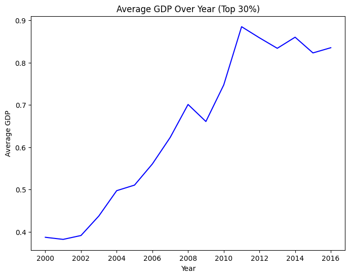

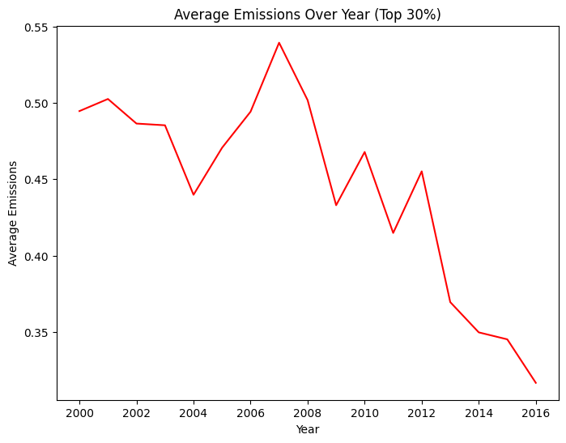

```python
aver_GDP = Top_30.groupby('Year')['Value'].mean()
aver_Emission = Top_30.groupby('Year')['Total'].mean()

plt.figure(figsize=(8, 6))
plt.plot(aver_GDP.index, aver_GDP.values, color='blue')
plt.title('Average GDP Over Year (Top 30%)')
plt.xlabel('Year')
plt.ylabel('Average GDP')
plt.show()

plt.figure(figsize=(8, 6))
plt.plot(aver_Emission.index, aver_Emission.values, color='red')
plt.title('Average Emissions Over Year (Top 30%)')
plt.xlabel('Year')
plt.ylabel('Average Emissions')
plt.show()
```

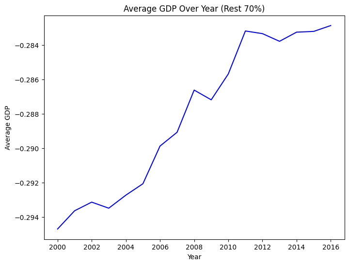

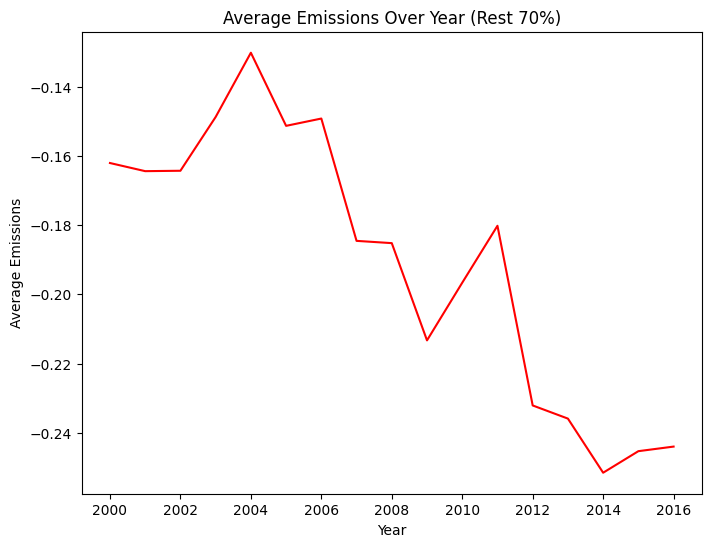

```python
aver_GDP = Rest_70.groupby('Year')['Value'].mean()
aver_Emission = Rest_70.groupby('Year')['Total'].mean()

plt.figure(figsize=(8, 6))
plt.plot(aver_GDP.index, aver_GDP.values, color='blue')
plt.title('Average GDP Over Year (Rest 70%)')
plt.xlabel('Year')
plt.ylabel('Average GDP')
plt.show()

plt.figure(figsize=(8, 6))
plt.plot(aver_Emission.index, aver_Emission.values, color='red')
plt.title('Average Emissions Over Year (Rest 70%)')
plt.xlabel('Year')
plt.ylabel('Average Emissions')
plt.show()
```

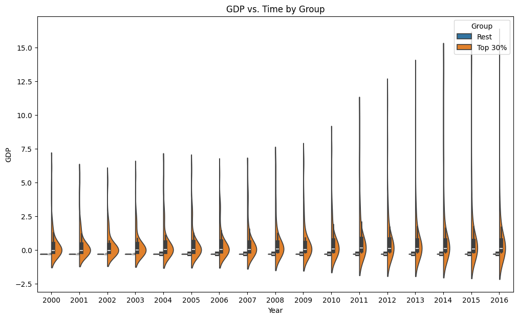

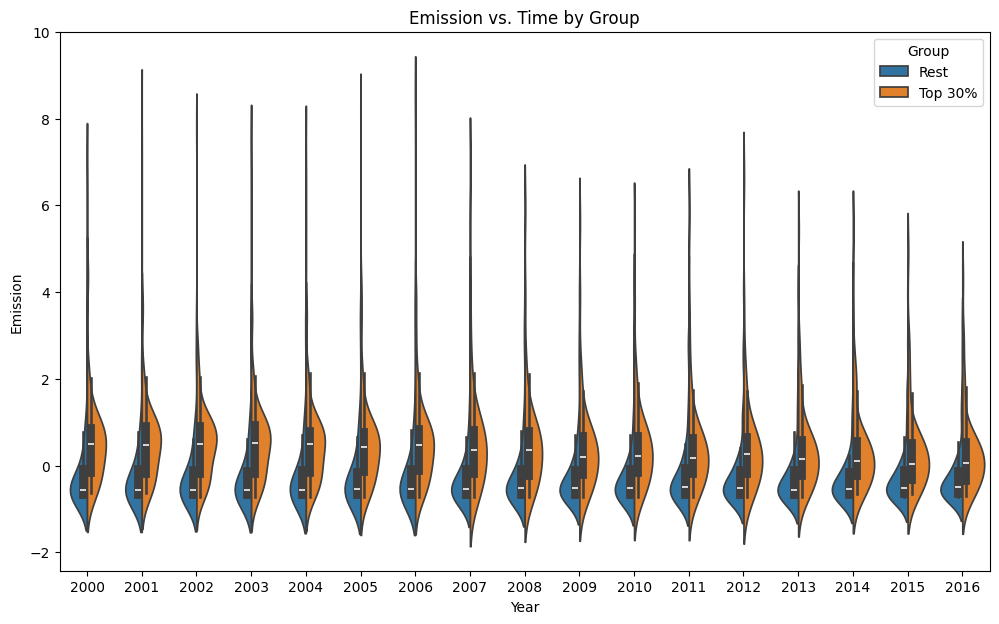

```python
plt.figure(figsize=(12, 7))
sns.violinplot(x='Year', y='Value', hue='Group', data=modified_1, split=True)
plt.title('GDP vs. Time by Group')
plt.xlabel('Year')
plt.ylabel('GDP')
plt.legend(title='Group')
plt.show()

plt.figure(figsize=(12, 7))
sns.violinplot(x='Year', y='Total', hue='Group', data=modified_1, split=True)
plt.title('Emission vs. Time by Group')
plt.xlabel('Year')
plt.ylabel('Emission')
plt.legend(title='Group')
plt.show()
```

According to the violin graph, it seems the range of GDP among the top 30% is becoming wider. However, the range of Emission is closer. Both of these and the decresing outliers indicate the Emission is decreasing. The Rest 70 is pretty stable.

## **Part 4: Analysis, hypothesis testing, & ML**

```python
for group, group_data in modified_1.groupby('Group'):
    result = smf.ols('Total ~ Value', data=group_data).fit()
    print(group,"\n",result.summary(),"\n")
```

```
Rest
                             OLS Regression Results
==============================================================================
Dep. Variable:                  Total   R-squared:                       0.036
Model:                            OLS   Adj. R-squared:                  0.036
Method:                 Least Squares   F-statistic:                     75.11
Date:                Wed, 15 May 2024   Prob (F-statistic):           9.03e-18
Time:                        22:34:21   Log-Likelihood:                -2664.4
No. Observations:                2006   AIC:                             5333.
Df Residuals:                    2004   BIC:                             5344.
Df Model:                           1
Covariance Type:            nonrobust
==============================================================================
                 coef    std err          t      P>|t|      [0.025      0.975]
------------------------------------------------------------------------------
Intercept      2.0298      0.257      7.905      0.000       1.526       2.533
Value          7.6917      0.888      8.666      0.000       5.951       9.432
==============================================================================
Omnibus:                     1721.070   Durbin-Watson:                   0.203
Prob(Omnibus):                  0.000   Jarque-Bera (JB):            50499.092
Skew:                           3.990   Prob(JB):                         0.00
Kurtosis:                      26.249   Cond. No.                         47.1
==============================================================================

Notes:
[1] Standard Errors assume that the covariance matrix of the errors is correctly specified.

Top 30%
                             OLS Regression Results
==============================================================================
Dep. Variable:                  Total   R-squared:                       0.000
Model:                            OLS   Adj. R-squared:                 -0.001
Method:                 Least Squares   F-statistic:                    0.2037
Date:                Wed, 15 May 2024   Prob (F-statistic):              0.652
Time:                        22:34:21   Log-Likelihood:                -1236.0
No. Observations:                 860   AIC:                             2476.
Df Residuals:                     858   BIC:                             2485.
Df Model:                           1
Covariance Type:            nonrobust
==============================================================================
                 coef    std err          t      P>|t|      [0.025      0.975]
------------------------------------------------------------------------------
Intercept      0.4328      0.038     11.516      0.000       0.359       0.507
Value          0.0096      0.021      0.451      0.652      -0.032       0.051
==============================================================================
Omnibus:                      463.919   Durbin-Watson:                   0.191
Prob(Omnibus):                  0.000   Jarque-Bera (JB):             3507.362
Skew:                           2.374   Prob(JB):                         0.00
Kurtosis:                      11.680   Cond. No.                         2.03
==============================================================================

Notes:
[1] Standard Errors assume that the covariance matrix of the errors is correctly specified.
```

```python
modified_2 = modified_1.copy()
np.random.seed(42)

modified_2['Simulated_Emissions'] = modified_2.apply(lambda row: row['Total'] *
                                                     (1 + np.random.uniform(0.05, 0.1)) if row['Year'] > 2000 else row['Total'], axis=1)
modified_2.head(5)
```

|  | Country | Country Code | Year | Value | ISO 3166-1 alpha-3 | Total | Coal | Oil | Gas | Cement | Flaring | Other | Group | Simulated_Emissions |
| --- | --- | --- | --- | --- | --- | --- | --- | --- | --- | --- | --- | --- | --- | --- |
| 22 | Afghanistan | AFG | 2001 | -0.304991 | AFG | -0.722354 | -0.470732 | -0.709122 | -0.342130 | -0.701219 | -0.217461 | -0.45404 | Rest | -0.771999 |
| 23 | Afghanistan | AFG | 2002 | -0.302797 | AFG | -0.720927 | -0.471240 | -0.710359 | -0.338393 | -0.700035 | -0.219731 | -0.45404 | Rest | -0.791243 |
| 24 | Afghanistan | AFG | 2003 | -0.302199 | AFG | -0.720178 | -0.470443 | -0.707579 | -0.339716 | -0.700600 | -0.219731 | -0.45404 | Rest | -0.782545 |
| 25 | Afghanistan | AFG | 2004 | -0.301275 | AFG | -0.722619 | -0.470535 | -0.709162 | -0.342363 | -0.700704 | -0.219731 | -0.45404 | Rest | -0.780380 |
| 26 | Afghanistan | AFG | 2005 | -0.299972 | AFG | -0.718904 | -0.470277 | -0.702868 | -0.341429 | -0.701698 | -0.219731 | -0.45404 | Rest | -0.760457 |

```python
X_Top30 = Top_30[['Year', 'Value']]
y_Top30 = Top_30['Total']

p = PolynomialFeatures(degree=5)
X_Top30_p = p.fit_transform(X_Top30)

X_Top30_train, X_Top30_test, y_Top30_train, y_Top30_test = train_test_split(X_Top30_p, y_Top30, test_size=0.2, random_state=100)

model_Top30 = LinearRegression()
model_Top30.fit(X_Top30_train, y_Top30_train)

X_rest = Rest_70[['Year', 'Value']]
y_rest = Rest_70['Total']

X_rest_train, X_rest_test, y_rest_train, y_rest_test = train_test_split(X_rest, y_rest, test_size=0.1, random_state=50)

model_rest = LinearRegression()
model_rest.fit(X_rest_train, y_rest_train)

y_Top30_pred = model_Top30.predict(X_Top30_test)
y_rest_pred = model_rest.predict(X_rest_test)

MSE_Top30 = mean_squared_error(y_Top30_test, y_Top30_pred)
MSE_rest = mean_squared_error(y_rest_test, y_rest_pred)

print(f"MSE Top 30%: {MSE_Top30}")
print(f"MSE Rest 70%: {MSE_rest}")

MSE = (mse_Top30 * len(y_Top30_test) + mse_rest * len(y_rest_test)) / (len(y_Top30_test) + len(y_rest_test))
print(f"MSE: {MSE}")
```

[output not shown]

## **Part 5: Interpretation: Insight & Policy Decision**

In this tutorial, we analyzed the complex relationships between GDP and Emissions among various countries. We have learned that constructing an accurate model concerning GDP and Emissions is challenging because it is influenced by multiple factors. However, by building this model, we can provide some references for policymakers, thereby ensuring that we are on the right path.